# Assignment_2

Yilin Bai

2022-10-24

#### The link to my GitHub Repo

[My GitHub Repository(%5Bhttps://github.com/YilinBai-hub/R.git)](https://github.com/YilinBai-hub/R.git)

#### 1. Correct analysis of Clark data to generate the summary statistics (means, SD, N) for each of the fish species’ average activity for each treatment.

**A. Libraries and Packages**

Install and load *tidyr, dplyr, plotrix, flextable, ggplot2, readr, orchaRd* package.

```r
library(tidyr)
library(dplyr)
```

```r
library('plotrix')
library('flextable')
library(ggplot2)
library(readr)
library(orchaRd)
```

**B. Import of the Csv file**

Download the files “OA_activitydat_20190302_BIOL3207.csv” file from the course Wattle site. Import of the file into R as a tibble by using `read_csv()` and have a general impression of all the data.

```r
path <- "./Data/OA_activitydat_20190302_BIOL3207.csv"
data_activity <- read_csv(path)
data_activity
```

```
## # A tibble: 589 × 9
##     ...1 loc       species treatment animal_id    sl size  activity comment
##    <dbl> <chr>     <chr>   <chr>         <dbl> <dbl> <chr>    <dbl> <chr>
##  1     1 LIRS 2014 ambon   CO2              64  57.0 big       8.15 27min means…
##  2     2 LIRS 2014 ambon   CO2              65  38.2 big      10.5  27min means…
##  3     3 LIRS 2014 ambon   CO2              67  39.3 big       6.51 27min means…
##  4     4 LIRS 2014 ambon   CO2              68  36.1 big      27.8  27min means…
##  5     5 LIRS 2014 lemon   CO2              74  36.4 big      36.7  27min means…
##  6     6 LIRS 2014 ambon   CO2              75  35.9 big      42.8  27min means…
##  7     7 LIRS 2014 lemon   CO2              81  35.7 big      21.9  27min means…
##  8     8 LIRS 2014 ambon   CO2              84  38.4 big      24.6  27min means…
##  9     9 LIRS 2014 ambon   CO2             222  34   big      NA    recording f…
## 10    10 LIRS 2014 ambon   CO2              85  48.3 big      35.1  27min means…
## # … with 579 more rows
## # ℹ Use `print(n = ...)` to see more rows
```

**C. Quality control of data to identify and address problematic entries**

There is some missing data in both `activity` and `animal_id` columns. Remove it with `filter(!is.na())`

```r
data_activity <- data_activity %>% filter(!is.na(activity))
data_activity <- data_activity %>% filter(!is.na(animal_id))
data_activity
```

```
## # A tibble: 550 × 9
##     ...1 loc       species treatment animal_id    sl size  activity comment
##    <dbl> <chr>     <chr>   <chr>         <dbl> <dbl> <chr>    <dbl> <chr>
##  1     1 LIRS 2014 ambon   CO2              64  57.0 big       8.15 27min means…
##  2     2 LIRS 2014 ambon   CO2              65  38.2 big      10.5  27min means…
##  3     3 LIRS 2014 ambon   CO2              67  39.3 big       6.51 27min means…
##  4     4 LIRS 2014 ambon   CO2              68  36.1 big      27.8  27min means…
##  5     5 LIRS 2014 lemon   CO2              74  36.4 big      36.7  27min means…
##  6     6 LIRS 2014 ambon   CO2              75  35.9 big      42.8  27min means…
##  7     7 LIRS 2014 lemon   CO2              81  35.7 big      21.9  27min means…
##  8     8 LIRS 2014 ambon   CO2              84  38.4 big      24.6  27min means…
##  9    10 LIRS 2014 ambon   CO2              85  48.3 big      35.1  27min means…
## 10    11 LIRS 2014 ambon   CO2              88  43.4 big       1.02 27min means…
## # … with 540 more rows
## # ℹ Use `print(n = ...)` to see more rows
```

**D. Generate the summary statistics**

Generate means, SD, N for each of the fish species’ average activity for each treatment by using `group_by()` and `summarise()` function separately. And use the `merge()` function to combine the two tibbles of control and treatment.

```r
control_acticity <- data_activity %>% group_by(species) %>% filter(treatment=="control")%>% summarise(ctrl.n =n(),ctrl.mean = mean(activity),ctrl.sd = sd(activity))

co2_activity <-  data_activity %>% group_by(species) %>% filter(treatment=="CO2")%>% summarise(oa.n =n(),oa.mean = mean(activity),oa.sd = sd(activity))

group_activity <-  merge(control_acticity,co2_activity)
group_activity
```

```
##     species ctrl.n ctrl.mean   ctrl.sd oa.n  oa.mean     oa.sd
## 1   acantho     90  28.92639 11.246347   86 27.30042 10.415559
## 2     ambon     21  17.34102 11.451588   22 18.39429 12.200326
## 3   chromis     20  26.09986  9.125352   14 24.78010 10.975005
## 4    humbug     65  34.91652 13.867278   62 40.28306 11.915992
## 5     lemon     30  19.79766 12.256353   19 26.04157 10.957164
## 6 whitedams     61  26.58624 10.936592   60 24.45733  9.950437
```

#### 2. Through coding, merge the summary statistics generated from 1 with the metadata from Clark et al. (2020).

Import of the file into R as a tibble by using `read_csv()`.

Because there are no shared columns in the two tables, we use the `merge()` function to add the columns from both tables and generate a new table “clark_total”.

```r
clark_paper_data <- read_csv("./Data/clark_paper_data.csv")
clark_total <- merge(clark_paper_data,group_activity)
clark_total
```

```
##   Study     Authors Year (online) Year (print)
## 1   a92 Clark et al          2020         2020
## 2   a92 Clark et al          2020         2020
## 3   a92 Clark et al          2020         2020
## 4   a92 Clark et al          2020         2020
## 5   a92 Clark et al          2020         2020
## 6   a92 Clark et al          2020         2020
##                                                                    Title
## 1 Ocean acidification does not impair the behaviour of coral reef fishes
## 2 Ocean acidification does not impair the behaviour of coral reef fishes
## 3 Ocean acidification does not impair the behaviour of coral reef fishes
## 4 Ocean acidification does not impair the behaviour of coral reef fishes
## 5 Ocean acidification does not impair the behaviour of coral reef fishes
## 6 Ocean acidification does not impair the behaviour of coral reef fishes
##   Journal Pub year IF 2017 IF Average n Effect type Climate (FishBase)
```

[output cut: 20 more lines]

#### 3. Through coding, correctly merge the combined summary statistics and metadata from Clark et al. (2020) (output from 1 & 2) into the larger meta-analysis dataset.

**A. Import of the file into R as a tibble by using `read_csv()` and have a general impression of all the data.**

```r
ocean_meta_data <- read_csv("./Data/ocean_meta_data.csv")
str(ocean_meta_data)
```

```
## spec_tbl_df [818 × 22] (S3: spec_tbl_df/tbl_df/tbl/data.frame)
##  $ Study             : chr [1:818] "a1" "a1" "a1" "a1" ...
##  $ Authors           : chr [1:818] "Munday et al" "Munday et al" "Munday et al" "Munday et al" ...
##  $ Year (online)     : num [1:818] 2009 2009 2009 2009 2009 ...
##  $ Year (print)      : num [1:818] 2009 2009 2009 2009 2009 ...
##  $ Title             : chr [1:818] "Ocean acidification impairs olfactory discrimination and homing ability of marine fish." "Ocean acidification impairs olfactory discrimination and homing ability of marine fish." "Ocean acidification impairs olfactory discrimination and homing ability of marine…
##  $ Journal           : chr [1:818] "PNAS" "PNAS" "PNAS" "PNAS" ...
##  $ Pub year IF       : chr [1:818] "9.432" "9.432" "9.432" "9.432" ...
##  $ 2017 IF           : chr [1:818] "9.504" "9.504" "9.504" "9.504" ...
##  $ Average n         : num [1:818] 27 27 27 27 27 27 27 15 15 15 ...
##  $ Effect type       : chr [1:818] "Strong" "Strong" "Strong" "Strong" ...
##  $ Species           : chr [1:818] "Amphiprion percula" "Amphiprion percula" "Amphiprion percula" "Amphiprion percula" ...
##  $ Climate (FishBase): chr [1:818] "Trop" "Trop" "Trop" "Trop" ...
##  $ Env cue/stimulus? : chr [1:818] "Yes" "Yes" "Yes" "Yes" ...
##  $ Cue/stimulus type : chr [1:818] "Habitat" "Habitat" "Habitat" "Habitat" ...
##  $ Behavioural metric: chr [1:818] "% time in Xanthostemon cue" "% time in Melaleuca cue" "% time in Grass cue" "% time in anemone cue" ...
##  $ Life stage        : chr [1:818] "Larvae" "Larvae" "Larvae" "Larvae" ...
##  $ ctrl.n            : num [1:818] 26 20 20 10 30 30 30 45 45 45 ...
##  $ ctrl.mean         : num [1:818] 94.129 0.783 46.38 98.826 0.912 ...
##  $ ctrl.sd           : num [1:818] 2.99 3.5 14 1.86 3 ...
##  $ oa.n              : num [1:818] 46 46 46 16 20 20 20 45 45 45 ...
##  $ oa.mean           : num [1:818] 72.8 83.6 71.4 88.3 99.8 ...
##  $ oa.sd             : num [1:818] 13.273 10.6211 13.273 7.044 0.0045 ...
##  - attr(*, "spec")=
##   .. cols(
##   ..   Study = col_character(),
##   ..   Authors = col_character(),
##   ..   `Year (online)` = col_double(),
##   ..   `Year (print)` = col_double(),
##   ..   Title = col_character(),
##   ..   Journal = col_character(),
##   ..   `Pub year IF` = col_character(),
##   ..   `2017 IF` = col_character(),
##   ..   `Average n` = col_double(),
##   ..   `Effect type` = col_character(),
##   ..   Species = col_character(),
##   ..   `Climate (FishBase)` = col_character(),
##   ..   `Env cue/stimulus?` = col_character(),
##   ..   `Cue/stimulus type` = col_character(),
##   ..   `Behavioural metric` = col_character(),
##   ..   `Life stage` = col_character(),
##   ..   ctrl.n = col_double(),
##   ..   ctrl.mean = col_double(),
##   ..   ctrl.sd = col_double(),
##   ..   oa.n = col_double(),
##   ..   oa.mean = col_double(),
##   ..   oa.sd = col_double()
##   .. )
##  - attr(*, "problems")=<externalptr>
```

**B. Compare the two tibbles, there are some differences that may affect the merging of tables**

First, change the coercion of two column “Pub year IF” and “2017 IF” into character by using the function `as.character()`.

```r
clark_total$"Pub year IF" <- as.character(clark_total$"Pub year IF")
clark_total$"2017 IF" <- as.character(clark_total$"2017 IF")
```

Second, the “species” column names in the two tables are case-sensitive. Modify them to make them consistent.

```r
colnames(clark_total)[16] <- "Species"
```

Third, I notice that in “ocean_meta_data2.csv”, if there is no environmental Cue/stimulus, a “-” is used in the “Cue/stimulus type” column, whereas in “clark_total”, The column “Cue/stimulus type” uses “NA”, so change “NA” into “-”.

```r
clark_total[is.na(clark_total)] <- "-"
```

**C. Merge two tables!**

```r
ocean_total <- bind_rows(clark_total,ocean_meta_data)
```

**D. Quality control of data to identify and address problematic entries**

According to the README file, the definition of activity column is **“Number of seconds the fish was active per minute, averaged across the duration of the trial.”**

Therefore, the data value of the `activity` should be greater than 0, and the values of the `ctrl.mean` and `oa.mean` should also be greater than 0. Filter the data by using the `filter()` function.

```r
ocean_total <- ocean_total %>% filter(ctrl.mean>0) %>% filter(oa.mean>0)
```

#### 4. Correctly calculate the log response ratio (lnRR) effect size for every row of the data frame using metafor’s `escalc()` function.

- ‘ROM’ - calculate the effect size (log response ratio of means) and sample variable of each row.
- ‘m1i’ and ‘m2i’ - the mean of treatment and control group
- ‘sd1i’ and ‘sd2i’ - the SD of treatment and control group. ‘n1i’ and ‘n2i’ - the sample size of treatment and control group.
- Add the lnRR and sample variation as two columns named as ‘lnRR’, ‘V_lnRR’.

```r
ocean_total <- metafor::escalc(measure = "ROM", m1i = oa.mean, m2i = ctrl.mean, sd1i =oa.sd
, sd2i = ctrl.sd, n1i = oa.n, n2i = ctrl.n, data = ocean_total, var.names = c("lnRR", "V_lnRR"))
```

#### 5. Correct meta-analytic model fitted to the data that controls for the sampling variance of lnRR. The model should include a random effect of study and observation. Use metafor’s `rma.mv()` function.

**A. Add in observation-level (`residual`) column.**

This column simply counts, from 1 to the number of rows. Add this to estimate the within study variation.

```r
ocean_total <- tibble::rowid_to_column(ocean_total, "residual")
```

**B. Filter out the NA values in effect size and sample variation which not contribute to the analyse.**

```r
ocean_total <- ocean_total %>% filter(!is.na(lnRR))
ocean_total <- ocean_total %>% filter(!is.na(V_lnRR))
```

**C. Filter out the data outliers**

- Some sample variance are very large, which may be data outliers.
- Because their sample variance is too large, it will lead to the instability of Multi-level meta-analytic model, which will also lead to difficulties in subsequent analysis and observation of publication bias.
- So I filtered out the three outlier values from the data.

```r
ocean_total <- ocean_total %>% filter(V_lnRR<5000)
```

**D. Build the Multi-level meta-analytic model**

```r
# Multi-level meta-analytic model
MLMA <- metafor::rma.mv(lnRR~1, V = V_lnRR,
                   method="REML",
                   random=list(~1|Study,
                               ~1|residual),
                   data=ocean_total)
MLMA
```

```
##
## Multivariate Meta-Analysis Model (k = 761; method: REML)
##
## Variance Components:
##
##             estim    sqrt  nlvls  fixed    factor
## sigma^2.1  0.4773  0.6909     92     no     Study
## sigma^2.2  4.1474  2.0365    761     no  residual
##
## Test for Heterogeneity:
## Q(df = 760) = 736088769.0039, p-val < .0001
##
## Model Results:
##
## estimate      se    zval    pval    ci.lb   ci.ub
##   0.1424  0.1152  1.2360  0.2164  -0.0834  0.3683
##
## ---
## Signif. codes:  0 '***' 0.001 '**' 0.01 '*' 0.05 '.' 0.1 ' ' 1
```

Use the `predict()`function to transfer the lnRR(log respond ratio) back to RR (Respond ratio).

```r
pis <- predict(MLMA,transf=exp)
pis
```

```
##
##    pred  ci.lb  ci.ub  pi.lb   pi.ub
##  1.1531 0.9200 1.4452 0.0169 78.5240
```

**E. Use `i2_ml()`function to estimate the proportion of Total Heterogeneity:** $I_{total}^2$

```r
i2_vals <- orchaRd::i2_ml(MLMA)
i2 <- tibble(type = firstup(gsub("I2_", "",names(i2_vals))), I2 = i2_vals)


flextable(i2) %>%
    align(part = "header", align = "center") %>%
  compose(part = "header", j = 1, value = as_paragraph(as_b("Type"))) %>%
  compose(part = "header", j = 2, value = as_paragraph(as_b("I"), as_b(as_sup("2")), as_b("(%)")))
```

| Type | I2(%) |
| --- | --- |
| Total | 100.00000 |
| Study | 10.32163 |
| Residual | 89.67837 |

#### 6. Written paragraph of the findings and what they mean which is supported with a figure.

**A. Correct presentation and interpretation of overall meta-analytic mean and measures of uncertainty around the mean estimate (e.g., 95% confidence intervals).**

**C. Forest plot showing the mean estimate, 95% confidence interval, and prediction interval with clearly labelled axes, number of samples and studies plotted on figure**

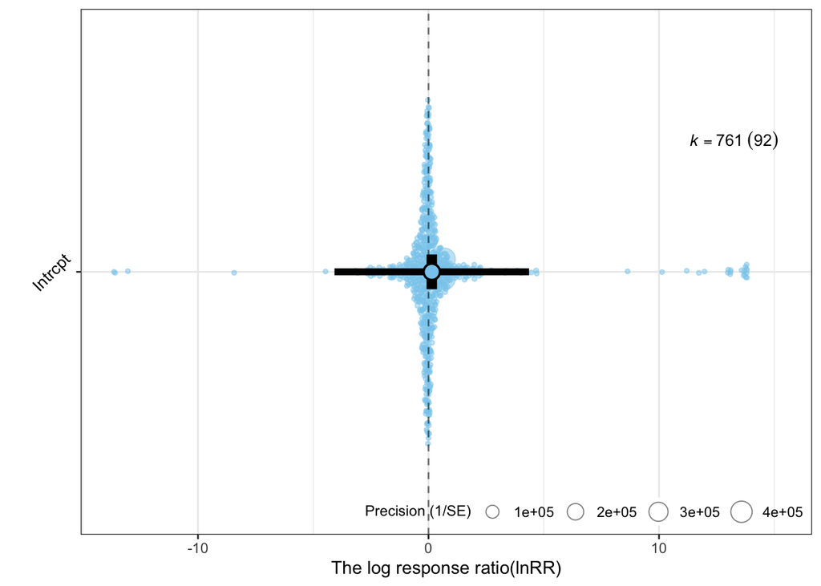

Figure 1: Forest plot showing the mean log response ratio between the treatment group and control group. k = the number of effect sizes and the number of studies are in brackets. The size of the effect is scaled by the precision of each effect size value, which is 1 / the sqrt(v_lnRR)

```r
orchaRd::orchard_plot(MLMA, group = "Study", data = ocean_total, xlab = "The log response ratio(lnRR)", angle = 45,trunk.size = 2,branch.size = 10,twig.size = 2)
```

#### 7. Funnel plot for visually assessing the possibility of publication bias.

**A. Generate the Funnel plot with the function `funnel()`.**

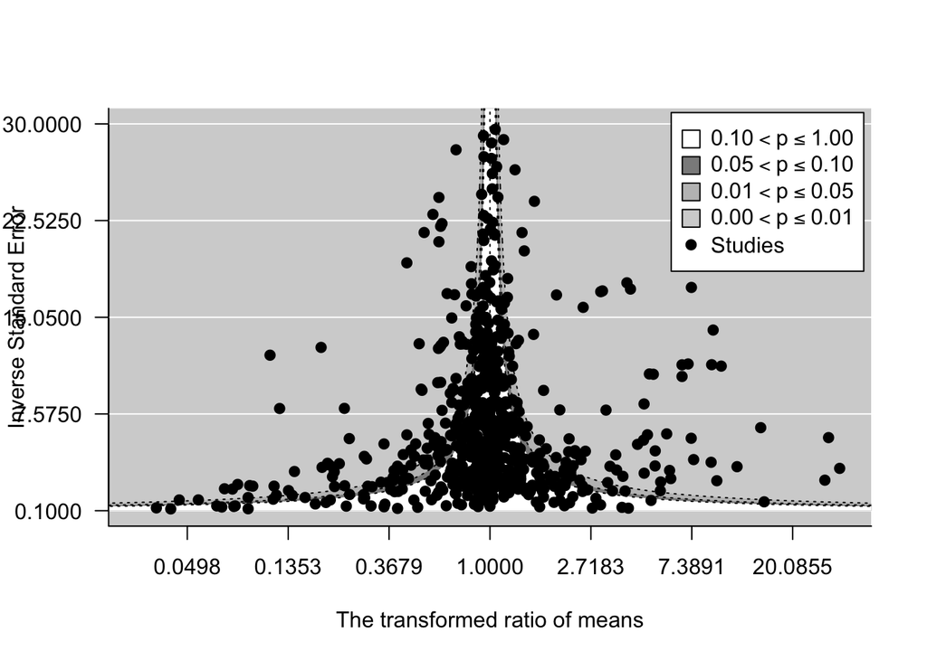

Figure 2: Funnel plot depicting the transformed ratio(RR) between the means of control and treatment group as a function of precision (1 / SE). The dotted lines are the theoretical 95% sampling variance intervals - the interval with which we expect effect size estimates to fall within if only sampling variance drives differences in effects. Shaded regions represent the p-value of studies. The white region indicates studies where the p-value is between 0.1 and 1; dark gray where the p-value of studies is between 0.05 and 0.1 and the lighter gray regions where the p-value of studies is significant. Adjust the ylim and xlim manually and several out group values are excluded for a better look

```r
metafor::funnel(x = ocean_total$lnRR, vi = ocean_total$V_lnRR, digits = 4, yaxis = "seinv",
                level = c(0.1, 0.05, 0.01),
                shade = c("white", "gray55", "gray 75"), las = 1,
                xlab = "The transformed ratio of means", legend = TRUE,ylim =c (0.1,30), atransf= exp,xlim = c(-3.5,3.5))
```

From Figure 2, I suspect there is no obvious file drawer effect.

The two sides of the data distribution is basically very uniform, there is no obvious blank area. The amount of data on both sides is almost equal.

**B. Plot of log transformed ratio of means against sampling variance for lnRR**

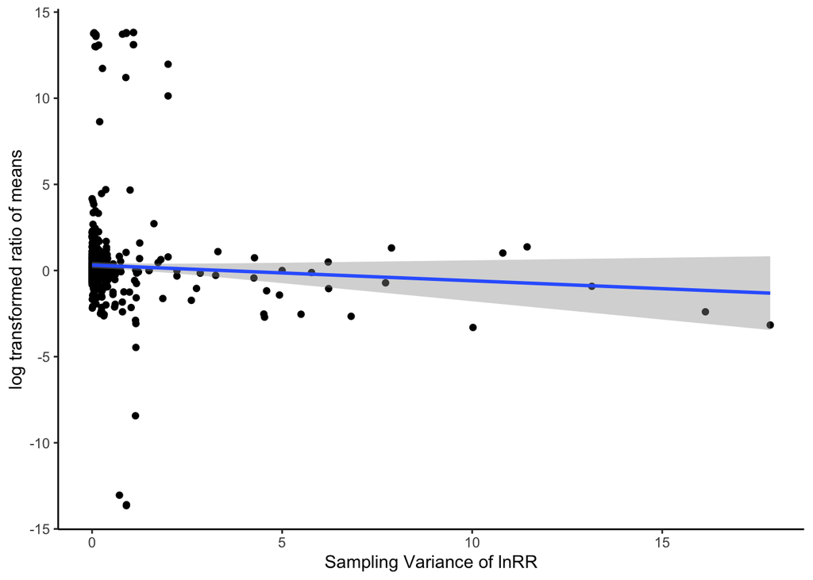

Figure 3: Plot of log transformed ratio of means against sampling variance for lnRR. A linear model was fit to the data.

```r
ggplot(ocean_total, aes(y = lnRR, x = V_lnRR)) +
  geom_point() +
  geom_smooth(method = lm) +
  labs(y = "log transformed ratio of means", x = "Sampling Variance of lnRR") +
  theme_classic()
```

As we can see from Figure 3, there is not a significant slope coefficient. However, there are still unequal effect size distributions on both sides of the figure, and when the sampling variance is high, the average lnRR shifts, resulting in a slope that is not equal to 0. But in this study, the shift was not large. I concluded that no significant ‘the file drawer effect’ appeared in these studies.

#### 8. Time-lag plot assessing how effect sizes may or may not have changed through time

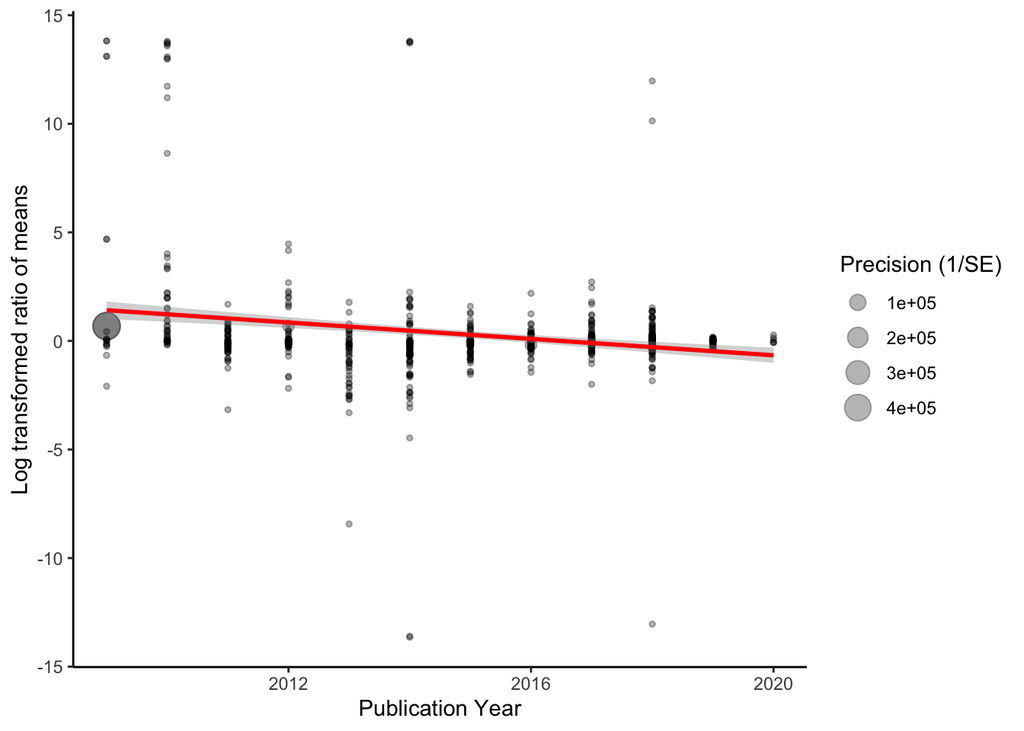

Figure 4: Plot of lnRR as a function of publication year. Points are scaled in relation to their precision (1/sqrt(V_lnRR)). Small points indicate effects with low precision or high sampling varaince

```r
ggplot(ocean_total, aes(y = lnRR, x = Year..online., size = 1/sqrt(V_lnRR))) + geom_point(alpha = 0.30) + geom_smooth(method = lm, col = "red", show.legend = FALSE) + labs(x = "Publication Year", y = "Log transformed ratio of means", size = "Precision (1/SE)") + theme_classic()
```

```r
num_less <- sum(1/sqrt(ocean_total$V_lnRR)>500)
```

1. There does appear to be a weak negative relationship with year.
2. There is not much difference between the precision in the early years and the precision in the recent years. There was even an earlier study that had the greatest precision, but it wasn’t statistically significant.
3. Earlier studies had some relatively large effect sizes, but they were few in number, and most effect sizes were closely distributed.
4. There seems to be no significant relationship between the size of the variance and the year, and the variance in early years is not much larger than in recent years.

#### 9. Formal meta-regression model that includes year as a moderator (fixed effect) to test for time-lag bias**

First, add a column indicating the difference between each year and the average year.

```r
ocean_total <- ocean_total %>% mutate(Year_diff = Year..online. - mean(Year..online.))
```

Then build the model including mean centered year as moderators.

```r
MLMA_time <- metafor::rma.mv(lnRR ~ Year_diff, V = V_lnRR,
                    random = list(~1|residual,
                                  ~1|Study),
                    test = "t", dfs = "contain",
                    data = ocean_total)
summary(MLMA_time)
```

```
##
## Multivariate Meta-Analysis Model (k = 761; method: REML)
##
##     logLik    Deviance         AIC         BIC        AICc
## -1692.3713   3384.7426   3392.7426   3411.2706   3392.7957
##
## Variance Components:
##
##             estim    sqrt  nlvls  fixed    factor
## sigma^2.1  4.1482  2.0367    761     no  residual
## sigma^2.2  0.3880  0.6229     92     no     Study
##
## Test for Residual Heterogeneity:
## QE(df = 759) = 128790346.4979, p-val < .0001
##
## Test of Moderators (coefficient 2):
## F(df1 = 1, df2 = 90) = 8.5208, p-val = 0.0044
##
## Model Results:
##
##            estimate      se     tval  df    pval    ci.lb    ci.ub
## intrcpt      0.1576  0.1098   1.4352  90  0.1547  -0.0606   0.3758
## Year_diff   -0.1198  0.0410  -2.9190  90  0.0044  -0.2013  -0.0383  **
##
## ---
## Signif. codes:  0 '***' 0.001 '**' 0.01 '*' 0.05 '.' 0.1 ' ' 1
```

```r
r2_time <- orchaRd::r2_ml(MLMA_time)
r2_time
```

```
##    R2_marginal R2_conditional
##     0.02481228     0.91659455
```

#### 10. Formal meta-regression model that includes inverse sampling variance (1/v_lnRR) to test for file-drawer biases.

```r
MLMA_drawer <- metafor::rma.mv(lnRR~1/V_lnRR, V = V_lnRR,
                   method="REML",
                   random=list(~1|Study,
                               ~1|residual),
                   data=ocean_total)
MLMA_drawer
```

```
##
## Multivariate Meta-Analysis Model (k = 761; method: REML)
##
## Variance Components:
##
##             estim    sqrt  nlvls  fixed    factor
## sigma^2.1  0.4773  0.6909     92     no     Study
## sigma^2.2  4.1474  2.0365    761     no  residual
##
## Test for Heterogeneity:
## Q(df = 760) = 736088769.0039, p-val < .0001
##
## Model Results:
##
## estimate      se    zval    pval    ci.lb   ci.ub
##   0.1424  0.1152  1.2360  0.2164  -0.0834  0.3683
##
## ---
## Signif. codes:  0 '***' 0.001 '**' 0.01 '*' 0.05 '.' 0.1 ' ' 1
```

```r
r2_drawer <- orchaRd::r2_ml(MLMA_drawer)
i2_drawer <- tibble::tibble(type = orchaRd::firstup(gsub("I2_", "",names(r2_drawer))), I2 = r2_drawer)
r2_drawer[[1]]
```

```
## [1] 0
```

Create a model that accounts for **both** of two effects(`sample variance` and `year`), and that accounts for the possible covariance between the two. And use `r2_ml()` functions to evaluate how much Heterogeneity does time when results were published explain in lnRR.

```r
MLMA_both <- metafor::rma.mv(lnRR ~ Year_diff + 1/V_lnRR, V = V_lnRR,
                    random=list(~1|Study,
                                ~1|residual),
                    test = "t", dfs = "contain",
                    data = ocean_total)

summary(MLMA_both)
```

```
##
## Multivariate Meta-Analysis Model (k = 761; method: REML)
##
##     logLik    Deviance         AIC         BIC        AICc
## -1692.3713   3384.7426   3392.7426   3411.2706   3392.7957
##
## Variance Components:
##
##             estim    sqrt  nlvls  fixed    factor
## sigma^2.1  0.3880  0.6229     92     no     Study
## sigma^2.2  4.1482  2.0367    761     no  residual
##
## Test for Residual Heterogeneity:
## QE(df = 759) = 128790346.4979, p-val < .0001
##
## Test of Moderators (coefficient 2):
## F(df1 = 1, df2 = 90) = 8.5208, p-val = 0.0044
##
## Model Results:
##
##            estimate      se     tval  df    pval    ci.lb    ci.ub
## intrcpt      0.1576  0.1098   1.4352  90  0.1547  -0.0606   0.3758
## Year_diff   -0.1198  0.0410  -2.9190  90  0.0044  -0.2013  -0.0383  **
##
## ---
## Signif. codes:  0 '***' 0.001 '**' 0.01 '*' 0.05 '.' 0.1 ' ' 1
```

```r
r2_time_sv <- orchaRd::r2_ml(MLMA_both)
r2_time_sv
```

```
##    R2_marginal R2_conditional
##     0.02481228     0.10821774
```

#### 11. A written paragraph that discusses the potential for publication bias based on the meta-regression results. What type of publication bias, if any, appears to be present in the data? If publication bias is present, what does it mean and what might be contributing to such bias?

Two kinds of publication bias was test in previous work: **the file-drawer bias and time-lag bias.**

#### 12. Identify any studies contributing to publication bias. How do your updated meta-analysis results compare with a meta-analysis by Clement et. al. (2022)? Are there any concerns about these studies? If so, describe using references to existing papers what concerns have been raised?

**The differences in method:**

1. First, only study and residual were considered as random effects in our study. However, Clement et. al. (2022) considered (1) cold-water species; (2) non-olfactory related behaviors; (3) Non-larval life stage and other influencing factors.
2. Secondly, some very extreme lnRR variance values were deleted in our study, but Clement et. al. (2022) did not delete them, but included them into consideration.
3. Then, Clement et. al. (2022) obtained the absolute value for lnRR, because many behavioral changes can be characterized by positive and negative functional trade-offs. But in my study, I kept the positive and negative values, so as to better observe the difference in mean value between the treatment group and the comparison group **and I wanted to know if ocean acidification had a positive or negative effect on behavior.**